# R Notebook

### plot time series of number of normal/referred customers registered

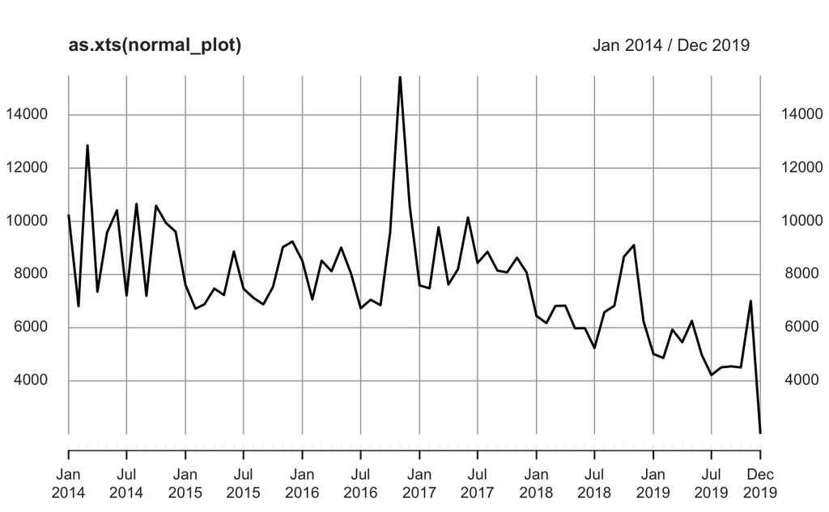

```r
dt2 <- data.table::as.data.table(mydata)
plotdata2 <- dt2[, .N, by = c('year_sub','month_sub')]
plotdata2 <-  plotdata2[with(plotdata2, order(year_sub, month_sub)), ]
plotdata2 <- plotdata2[,3]
normal_plot <- ts(plotdata2, frequency = 12, start = 2014)
temdata <- subset(referdata, referred == "1")
dt <- data.table::as.data.table(temdata)
plotdata <- dt[, .N, by = c('year_sub','month_sub')]
plotdata <-  plotdata[with(plotdata, order(year_sub, month_sub)), ]
plotdata <- plotdata[,3]
referral_plot <- ts(plotdata, frequency = 12, start = 2014)

# plot the number of customers registered, by year-month
plot(as.xts(normal_plot), major.format = "%Y-%m")
```

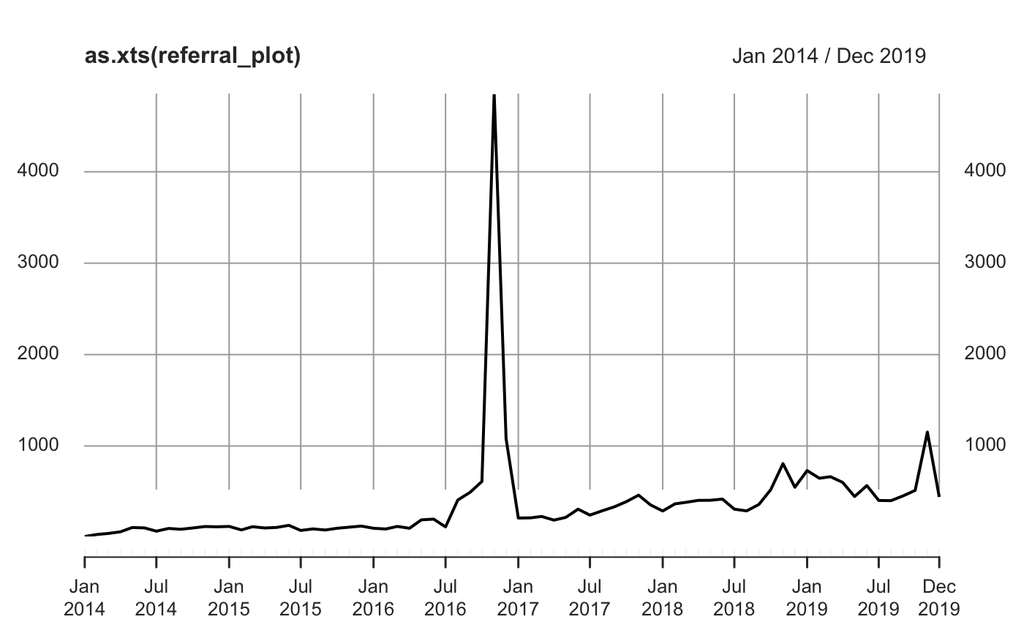

```r
# there is a peak on November 2016

# plot the number of referred customers registered, by year-month
plot(as.xts(referral_plot), major.format = "%Y-%m")
```

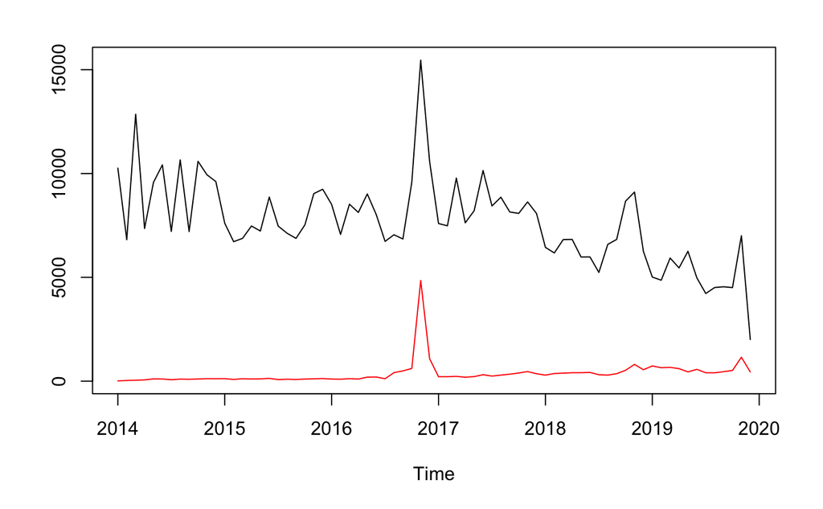

```r
# there is large peak on November 2016

# plot both of the number of normal/referred customers registered
ts.plot(referral_plot, normal_plot, gpars = list(col = c("red", "black")))
```

From the plot we can see that the amount of customers registered is slowly decreasing. However, the number of referred customers is slowly increasing, peaked on November in 2016 (when 4849 customers entered through referral). but we will not look into this because we focus on analyze referral behaviors in normal situations.

# Calculate CRV of each customer using recursion

```r
# sum excluding the referrer itself
# define the function "sum_children"
sum_children <- function(ID, data)
{
  result <- 0;
  children <- which(data$father_ID == ID)
  if(length(children) == 0)
    return(data$totalspend[which(data$ID == ID)])
  else
    for(i in seq_along(children))
      result <- result + sum_children(data$ID[children[i]], data)
    return(result)
}
```

```r
# sum including the referrer itself
# define the function "sum_children_incl"
sum_children_incl <- function(ID, data)
{
  result <- 0;
  children <- which(data$father_ID == ID)
  if(length(children) == 0)
    return(data$totalspend[which(data$ID == ID)])
  else
    result <- data$totalspend[which(data$ID == ID)]
    for(i in seq_along(children))
      result <- result + data$totalspend[children[i]]
    return(result)
}
```

```r
# apply the functions on data
referdata$child_sum <- lapply(referdata$ID, sum_children, referdata)
referdata$child_sum_incl <- lapply(referdata$ID, sum_children_incl, referdata)

# unlist lists child_sum & child_sum_incl
referdata$child_sum <- purrr:::reduce(referdata$child_sum, rbind.data.frame)
referdata$child_sum_incl <- purrr:::reduce(referdata$child_sum_incl, rbind.data.frame)

# adjust variable "child_sum"
referdata$child_sum_adjusted <- ifelse(referdata$child_sum == referdata$child_sum_incl, 0, referdata$child_sum)
referdata$child_sum <- NULL
# the variable child_sum_adjusted is the final result of Customer Referral Value
```

```r
# merge one column ("child_sum_adjusted") by FirstOrderDate to mydata table
mydata.join <- merge(x = mydata, y = referdata[ , c("FirstOrderDate", "child_sum_adjusted")], by = "FirstOrderDate", all.x=TRUE)

# replace NAs in mydata$child_sum_adjusted with 0
mydata.join[, 30][is.na(mydata.join[, 30])] <- 0
```

```r
# CRV comparison: referred customers vs. non-referred customers
mean(mydata.join$child_sum_adjusted[mydata.join$referred == 0])
```

```
[1] 9.280623
```

```r
mean(mydata.join$child_sum_adjusted[mydata.join$referred == 1])
```

```
[1] 24.89686
```

# who to target for referral program - customers with high CLV?

Question: are customers with high CLV the same as those with high CRV?

customer deciles of CLV (totalspend) and CRV (child_sum_adjusted):

```r
# assign each record with decile based on totalspend (CLV)
mydata.join$decile <- ntile(mydata.join$totalspend, 10)

mean(mydata.join$child_sum_adjusted[mydata.join$decile == 1])
```

```
[1] 1.405678
```

```r
mean(mydata.join$child_sum_adjusted[mydata.join$decile == 2])
```

```
[1] 1.556753
```

```r
mean(mydata.join$child_sum_adjusted[mydata.join$decile == 3])
```

```
[1] 2.591184
```

```r
mean(mydata.join$child_sum_adjusted[mydata.join$decile == 4])
```

```
[1] 3.151002
```

```r
mean(mydata.join$child_sum_adjusted[mydata.join$decile == 5])
```

```
[1] 3.080816
```

```r
mean(mydata.join$child_sum_adjusted[mydata.join$decile == 6])
```

```
[1] 4.491882
```

```r
mean(mydata.join$child_sum_adjusted[mydata.join$decile == 7])
```

```
[1] 6.527075
```

```r
mean(mydata.join$child_sum_adjusted[mydata.join$decile == 8])
```

```
[1] 8.392236
```

```r
mean(mydata.join$child_sum_adjusted[mydata.join$decile == 9])
```

```
[1] 14.6011
```

```r
mean(mydata.join$child_sum_adjusted[mydata.join$decile == 10])
```

```
[1] 54.41682
```

```r
mean(mydata.join$totalspend[mydata.join$decile == 1])
```

```
[1] 17.20279
```

```r
mean(mydata.join$totalspend[mydata.join$decile == 2])
```

```
[1] 33.72087
```

```r
mean(mydata.join$totalspend[mydata.join$decile == 3])
```

```
[1] 50.6519
```

```r
mean(mydata.join$totalspend[mydata.join$decile == 4])
```

```
[1] 73.19744
```

```r
mean(mydata.join$totalspend[mydata.join$decile == 5])
```

```
[1] 105.6883
```

```r
mean(mydata.join$totalspend[mydata.join$decile == 6])
```

```
[1] 156.8025
```

```r
mean(mydata.join$totalspend[mydata.join$decile == 7])
```

```
[1] 245.8087
```

```r
mean(mydata.join$totalspend[mydata.join$decile == 8])
```

```
[1] 419.8054
```

```r
mean(mydata.join$totalspend[mydata.join$decile == 9])
```

```
[1] 854.1616
```

```r
mean(mydata.join$totalspend[mydata.join$decile == 10])
```

```
[1] 4336.903
```

```r
# add a decile table of CLV (totalspend) correspond with CRV (child_sum_adjusted)
```

Who to target by each customer’s CLV? Analysis:

```r
# if target referral campaign on cusotmer with top 10% total spend: generate 55% referral value in total
sum(mydata.join$child_sum_adjusted[mydata.join$totalspend >= 1300])/sum(mydata.join$child_sum_adjusted)
```

```
[1] 0.5483241
```

```r
# if target referral campaign on cusotmer with top 15% total spend: generate 63% referral value in total
sum(mydata.join$child_sum_adjusted[mydata.join$totalspend >= 810])/sum(mydata.join$child_sum_adjusted)
```

```
[1] 0.632811
```

```r
# if target referral campaign on cusotmer with top 20% total spend: generate 69% referral value in total
sum(mydata.join$child_sum_adjusted[mydata.join$totalspend >= 560])/sum(mydata.join$child_sum_adjusted)
```

```
[1] 0.6889408
```

```r
# if target referral campaign on cusotmer with top 30% total spend: generate 77% referral value in total
sum(mydata.join$child_sum_adjusted[mydata.join$totalspend >= 310])/sum(mydata.join$child_sum_adjusted)
```

```
[1] 0.7730139
```

```r
# if target referral campaign on cusotmer with top 40% total spend: generate 84% referral value in total
sum(mydata.join$child_sum_adjusted[mydata.join$totalspend >= 193])/sum(mydata.join$child_sum_adjusted)
```

```
[1] 0.8375733
```

```r
# if target referral campaign on cusotmer with top 50% total spend: generate 88% referral value in total
sum(mydata.join$child_sum_adjusted[mydata.join$totalspend >= 127])/sum(mydata.join$child_sum_adjusted)
```

```
[1] 0.8839553
```

```r
# if target referral campaign on cusotmer with top 60% total spend: generate 91% referral value in total
sum(mydata.join$child_sum_adjusted[mydata.join$totalspend >= 89])/sum(mydata.join$child_sum_adjusted)
```

```
[1] 0.9130057
```

```r
# thus, the customers who are referred by high CLV customers (e.g. with top 10% spending), their total spend are above average.
```

# Rgression Analysis on Customer Referral Value

since we only need to draw inference of the data instead of making predictions, we don’t need to make the training/test split and predict.

```r
regr_CRV <- lm(child_sum_adjusted ~ referred + generation + totalspend + optin + year_sub + acquisition_source + gender + region + has_FB_link + sumvdays + sumvfriends + actyear, data=mydata.join)
summary(regr_CRV)
```

```
Call:
lm(formula = child_sum_adjusted ~ referred + generation + totalspend +
    optin + year_sub + acquisition_source + gender + region +
    has_FB_link + sumvdays + sumvfriends + actyear, data = mydata.join)

Residuals:
   Min     1Q Median     3Q    Max
 -5140    -10      2      8  76323

Coefficients: (1 not defined because of singularities)
                                      Estimate Std. Error t value Pr(>|t|)
(Intercept)                          4.952e+03  4.865e+02  10.178  < 2e-16 ***
referred                             1.153e+01  2.042e+00   5.647 1.64e-08 ***
generation                           1.260e+00  5.720e-01   2.202  0.02765 *
totalspend                           5.092e-03  1.861e-04  27.363  < 2e-16 ***
optinTRUE                           -1.203e+00  7.578e-01  -1.588  0.11233
year_sub                            -2.461e+00  2.412e-01 -10.201  < 2e-16 ***
acquisition_sourceMember Get Member         NA         NA      NA       NA
acquisition_sourceOrganic Social    -2.974e+00  6.824e+00  -0.436  0.66300
acquisition_sourceOther             -9.975e-01  1.506e+00  -0.662  0.50780
acquisition_sourcePaid Search        2.319e+00  9.837e-01   2.358  0.01839 *
acquisition_sourcePaid Social        3.008e+00  1.162e+00   2.590  0.00961 **
genderM                             -5.519e-01  8.136e-01  -0.678  0.49756
regionBE-NL                          3.502e+00  8.771e-01   3.993 6.51e-05 ***
regionNL-NL                          5.052e+00  9.130e-01   5.534 3.13e-08 ***
has_FB_link                         -2.017e+00  8.191e-01  -2.462  0.01381 *
sumvdays                            -3.084e-02  1.977e-03 -15.599  < 2e-16 ***
sumvfriends                          1.702e+01  1.435e-01 118.574  < 2e-16 ***
actyear                              8.148e-01  4.375e-01   1.862  0.06256 .
---
Signif. codes:  0 ‘***’ 0.001 ‘**’ 0.01 ‘*’ 0.05 ‘.’ 0.1 ‘ ’ 1

Residual standard error: 256.2 on 551231 degrees of freedom
Multiple R-squared:  0.03219,   Adjusted R-squared:  0.03216
F-statistic:  1146 on 16 and 551231 DF,  p-value: < 2.2e-16
```

```r
# the quality of the model can be analysed by the result of:
# (to do later): Residuals, Residual standard error, Multiple R-squared, Adjusted R-squared, F-statistic, p-value
```

- interpret the table, grouping variable into categories. (journal of “Driving profitability by encouraging”, p.13)

# ROI analysis for referral campaign

method 1:

```r
mean(mydata$totalspend[mydata$referred == 1])-20
```

```
[1] 212.1989
```

method 2:

```r
# total profit for referral program
totalprofit <- sum(mydata$totalspend[mydata$referred == 1])-nrow(mydata[which(mydata$referred ==1),])*20
totalprofit
```

```
[1] 5548152
```

```r
# total cost for referral program
totalcost <- nrow(mydata[which(mydata$referred ==1),])*20
totalcost
```

```
[1] 522920
```

```r
totalprofit/totalcost
```

```
[1] 10.60994
```

# how much percentage of referred customers generate profit for the firm (totalspend > referral cost of 20 euros)

assuming totalspend is after the deduction of 10 euros per referred customer, so we still need to deduct 10 euros (which are rewarded to the refering customer)

```r
nrow(referdata[which(referdata$totalspend > 10 & referdata$referred == 1),])/nrow(referdata[which(referdata$referred == 1),])
```

```
[1] 0.8000076
```

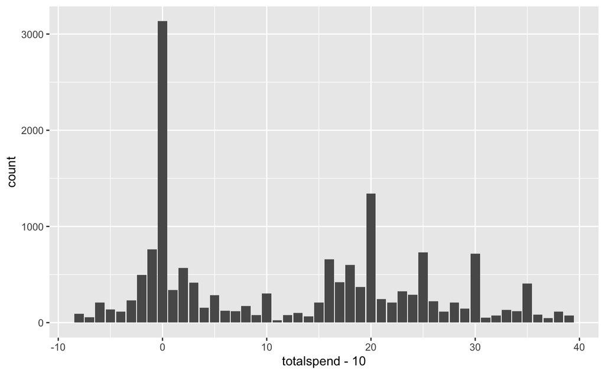

```r
ggplot(data = data.frame(referdata[referdata$referred == 1 & referdata$totalspend < 50,]), aes(totalspend-10)) + geom_bar()
```

```r
# customers
```